```python
import pandas as pd
from sklearn.tree import DecisionTreeClassifier
from sklearn.model_selection import train_test_split
import matplotlib.pyplot as plt
from sklearn import tree
from sklearn.tree import DecisionTreeClassifier, plot_tree
```

### Question:

1- Make the decision tree for Data of Week 8.

X: FMC DMC DC ISI temp RH wind

Y: month

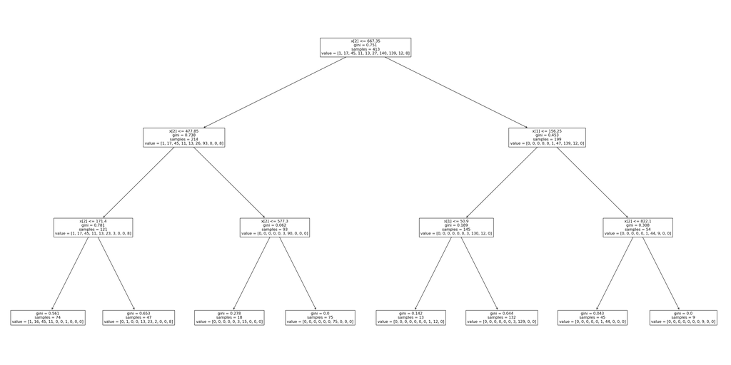

```python
data = pd.read_csv('Data-Week8.csv')
X = data[['FFMC', 'DMC', 'DC', 'ISI', 'temp', 'RH', 'wind']]
y = data['month']

# Split into training and test set
X_train, X_test, y_train, y_test = train_test_split(X, y, test_size = 0.2)
clf = DecisionTreeClassifier(random_state=0, max_depth=3)
clf = clf.fit(X_train, y_train)

plt.figure(figsize=(40,20))
tree.plot_tree(clf, fontsize=10, feature_names=X.columns, class_names=str(y.unique()))

# visualize the tree
tree.plot_tree(clf)
plt.show()
```

### 2- Interpret the decision tree based on Gini of each node.

Ans:

The decision tree mainly splits based on the feature X[2].

--> Nodes with a Gini impurity of 0 are pure, meaning all samples in that node belong to a single class.

--> The tree uses both X[2] and X[1] for making decisions.

--> Lower Gini values indicate clearer or more confident classifications by the tree.

In essence, X[2] appears to be a significant feature for predicting the target variable.

### 3- Find the month with the highest forest fires? Could you find the reason from Tree?

Ans:

Each node contains a "value" list, which represents the count of samples for each month.

To find the month with the highest forest fires, we need to find the largest value in any of these lists.